# Exploratory Data Analysis

STOR 320.405 Group 12

November 11, 2022

```r
#Load datasets
dataset = read.csv('Speed Dating Data.csv')
speed_dating <- dataset
df = dataset

dataset$iid <- as.factor(dataset$iid)
dataset$id <- as.factor(dataset$id)
dataset$pid <- as.factor(dataset$pid)
dataset$idg <- as.factor(dataset$idg)
dataset$gender <- as.factor(dataset$gender)
dataset$condtn <- as.factor(dataset$condtn)
dataset$wave <- as.factor(dataset$wave)
dataset$match <- as.factor(dataset$match)
dataset$samerace <- as.factor(dataset$samerace)
dataset$race_o <- as.factor(dataset$race_o)
dataset$dec_o <- as.factor(dataset$dec_o)
dataset$zipcode <- as.factor(dataset$zipcode)
dataset$race <- as.factor(dataset$race)
dataset$goal <- as.factor(dataset$goal)
dataset$date <- as.factor(dataset$date)
dataset$go_out <- as.factor(dataset$go_out)
dataset$field_cd <- as.factor(dataset$field_cd)
dataset$career_c <- as.factor(dataset$career_c)
dataset$length <- as.factor(dataset$length)
dataset$numdat_2 <- as.factor(dataset$numdat_2)
dataset$mn_sat <- as.numeric(gsub(",","",levels(dataset$mn_sat)))[dataset$mn_sat]
dataset$date_3 <- as.factor(dataset$date_3)
```

# Creator: Yihang Hu

### Q1: Does people estimate themselves just like how others estimate them?

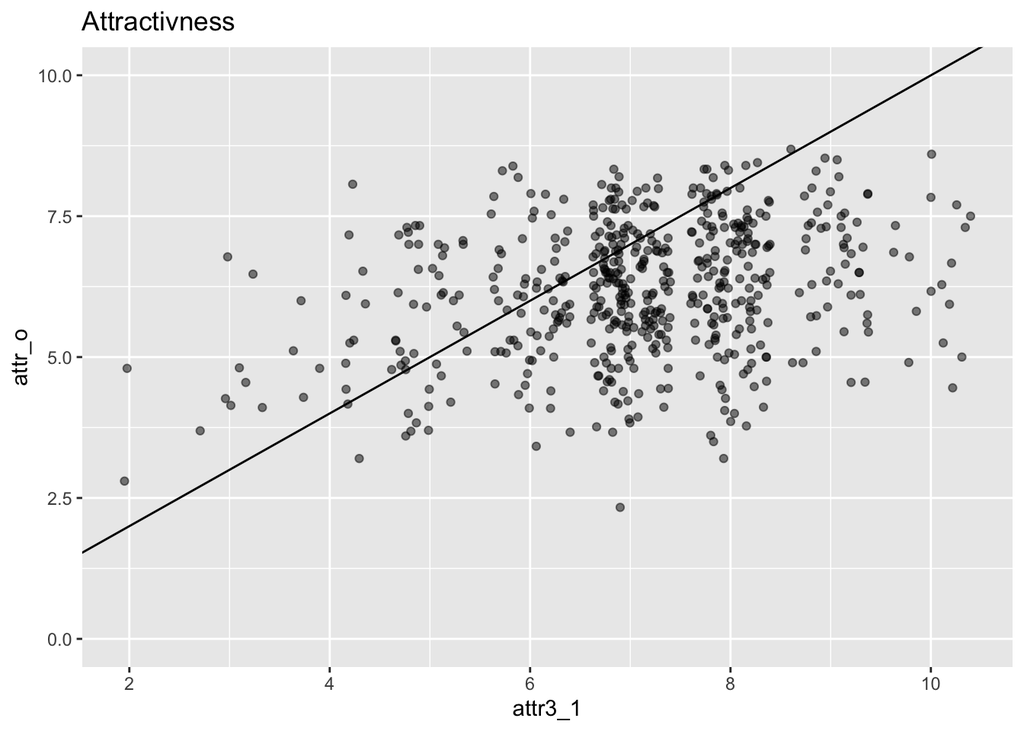

```r
outside.est <- aggregate(dataset[,c("iid", "gender", "age",
                                "attr3_1", "sinc3_1", "intel3_1",
                               "fun3_1", "amb3_1",
                               "attr_o", "sinc_o", "intel_o",
                               "fun_o", "amb_o")],
                    by = list(dataset$iid),
                    function (x) mean(x, na.rm = TRUE))
ggplot(outside.est, aes(x=attr3_1, y=attr_o)) +
  geom_point(position="jitter", alpha=0.5) +
  geom_abline() +
  scale_y_continuous(limits=c(0,10)) +
  ggtitle("Attractivness")
```

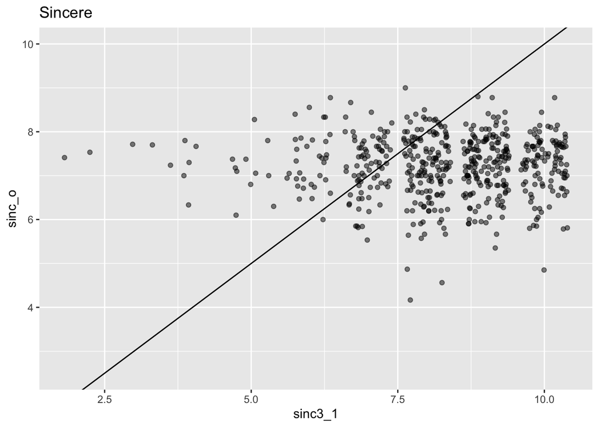

```r
ggplot(outside.est, aes(x=sinc3_1, y=sinc_o)) +
  geom_point(position="jitter", alpha=0.5) +
  geom_abline() +
  scale_y_continuous(limits=c(2.5,10)) +
  ggtitle("Sincere")
```

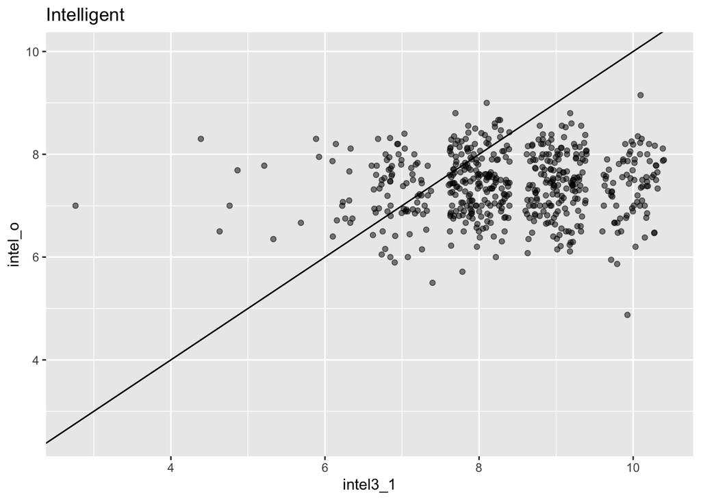

```r
ggplot(outside.est, aes(x=intel3_1, y=intel_o)) +
  geom_point(position="jitter", alpha=0.5) +
  geom_abline() +
  scale_y_continuous(limits=c(2.5,10)) +
  ggtitle("Intelligent")
```

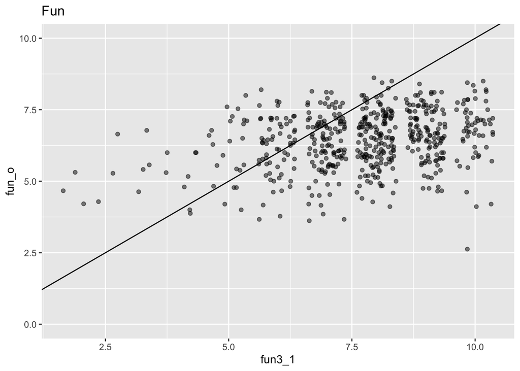

```r
ggplot(outside.est, aes(x=fun3_1, y=fun_o)) +
  geom_point(position="jitter", alpha=0.5) +
  geom_abline() +
  scale_y_continuous(limits=c(0,10)) +
  ggtitle("Fun")
```

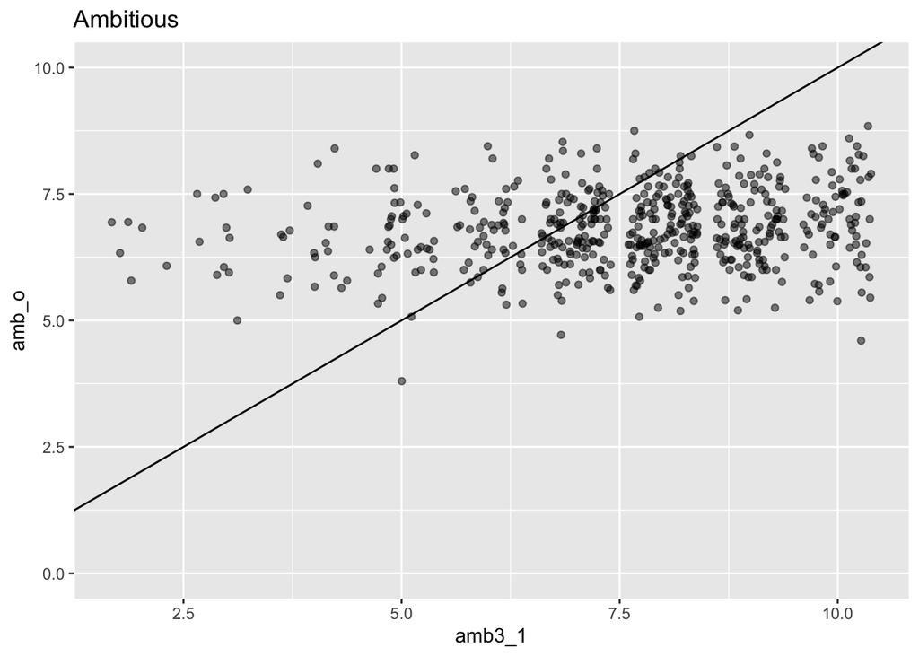

```r
ggplot(outside.est, aes(x=amb3_1, y=amb_o)) +
  geom_point(position="jitter", alpha=0.5) +
  geom_abline() +
  scale_y_continuous(limits=c(0,10)) +
  ggtitle("Ambitious")
```

On average, people seem to overestimate themselves. Only for attract and fun variation in estimates is quite high. For all other characteristics people tend to give average estimates (In order to see these characteristics in a person much more time is needed)

### Q2: How happy do people expect to be with the people you meet during the speed-dating event according to their goals?

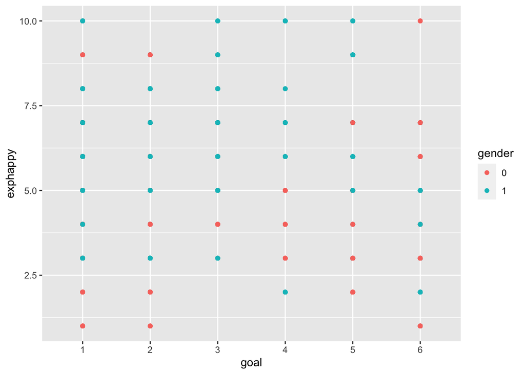

```r
dataset = dataset %>% drop_na(exphappy,goal,gender)
ggplot(data = dataset) +
    geom_point(aes(x = goal, y = exphappy, colour = gender))
```

```r
mod_exphappy = lm(exphappy~goal, data = dataset)
summary(mod_exphappy)
```

```
##
## Call:
## lm(formula = exphappy ~ goal, data = dataset)
##
## Residuals:
##     Min      1Q  Median      3Q     Max
## -4.7576 -0.7576  0.2424  1.2424  5.3938
##
## Coefficients:
##             Estimate Std. Error t value Pr(>|t|)
## (Intercept)  5.45388    0.02912 187.285  < 2e-16 ***
## goal2        0.30376    0.04250   7.147 9.63e-13 ***
## goal3        0.66657    0.07364   9.052  < 2e-16 ***
## goal4        0.02121    0.10217   0.208    0.836
## goal5       -0.63231    0.08067  -7.838 5.15e-15 ***
## goal6       -0.84767    0.08796  -9.637  < 2e-16 ***
## ---
## Signif. codes:  0 '***' 0.001 '**' 0.01 '*' 0.05 '.' 0.1 ' ' 1
##
## Residual standard error: 1.699 on 8271 degrees of freedom
## Multiple R-squared:  0.04059,    Adjusted R-squared:  0.04001
## F-statistic: 69.98 on 5 and 8271 DF,  p-value: < 2.2e-16
```

```r
dataset_men = subset(dataset, gender=="1")
mod_exphappy_men = lm(exphappy~goal, data = dataset_men)
summary(mod_exphappy_men)
```

```
##
## Call:
## lm(formula = exphappy ~ goal, data = dataset_men)
##
## Residuals:
##    Min     1Q Median     3Q    Max
## -4.250 -0.912  0.088  1.088  4.088
##
## Coefficients:
##             Estimate Std. Error t value Pr(>|t|)
## (Intercept)  5.91202    0.03842 153.897  < 2e-16 ***
## goal2       -0.05195    0.05793  -0.897  0.36993
## goal3        0.62485    0.08596   7.269  4.3e-13 ***
## goal4        0.33798    0.12805   2.640  0.00833 **
## goal5        0.08371    0.11155   0.750  0.45304
## goal6       -1.39463    0.11240 -12.408  < 2e-16 ***
## ---
## Signif. codes:  0 '***' 0.001 '**' 0.01 '*' 0.05 '.' 0.1 ' ' 1
##
## Residual standard error: 1.602 on 4168 degrees of freedom
## Multiple R-squared:  0.05657,    Adjusted R-squared:  0.05543
## F-statistic: 49.98 on 5 and 4168 DF,  p-value: < 2.2e-16
```

```r
dataset_women = subset(dataset, gender=="0")
mod_exphappy_women = lm(exphappy~goal, data = dataset_women)
summary(mod_exphappy_women)
```

```
##
## Call:
## lm(formula = exphappy ~ goal, data = dataset_women)
##
## Residuals:
##     Min      1Q  Median      3Q     Max
## -4.6727 -0.9754  0.0246  1.1739  5.2857
##
## Coefficients:
##             Estimate Std. Error t value Pr(>|t|)
## (Intercept)  4.97538    0.04074 122.111  < 2e-16 ***
## goal2        0.69736    0.05778  12.070  < 2e-16 ***
## goal3        0.22767    0.12526   1.818 0.069210 .
## goal4       -0.53351    0.15194  -3.511 0.000451 ***
## goal5       -1.14929    0.10805 -10.637  < 2e-16 ***
## goal6       -0.26109    0.12761  -2.046 0.040825 *
## ---
## Signif. codes:  0 '***' 0.001 '**' 0.01 '*' 0.05 '.' 0.1 ' ' 1
##
## Residual standard error: 1.663 on 4097 degrees of freedom
## Multiple R-squared:  0.08745,    Adjusted R-squared:  0.08634
## F-statistic: 78.53 on 5 and 4097 DF,  p-value: < 2.2e-16
```

# Interpreter: Ivan Wang

### Q1: What race has most people looking for speed dating?

```r
# Data Cleaning
# 1. Transform 'gender' variables (Female = 0; Male = 1)
speed_dating$gender <- ifelse(speed_dating$gender == 0, 'Female', 'Male')

# 2. Transform 'match' variable (Yes = 1; No = 0)
speed_dating$match <- ifelse(speed_dating$match == 1, 'Yes', 'No')
```

```r
# Further data-cleaning (delete rows containing 'NA' in the 'race' column)
sd_race <- speed_dating[!is.na(speed_dating$race),]
```

```r
#Prepare descriptions of different race groups
#(Black/African American=1
#European/Caucasian-American=2
#Latino/Hispanic American=3
#Asian/Pacific Islander/Asian-American=4
#Native American=5
#Other=6)
race_des <- c('African American', 'European', 'Latino', 'Asian', 'Native American', 'Other')
```

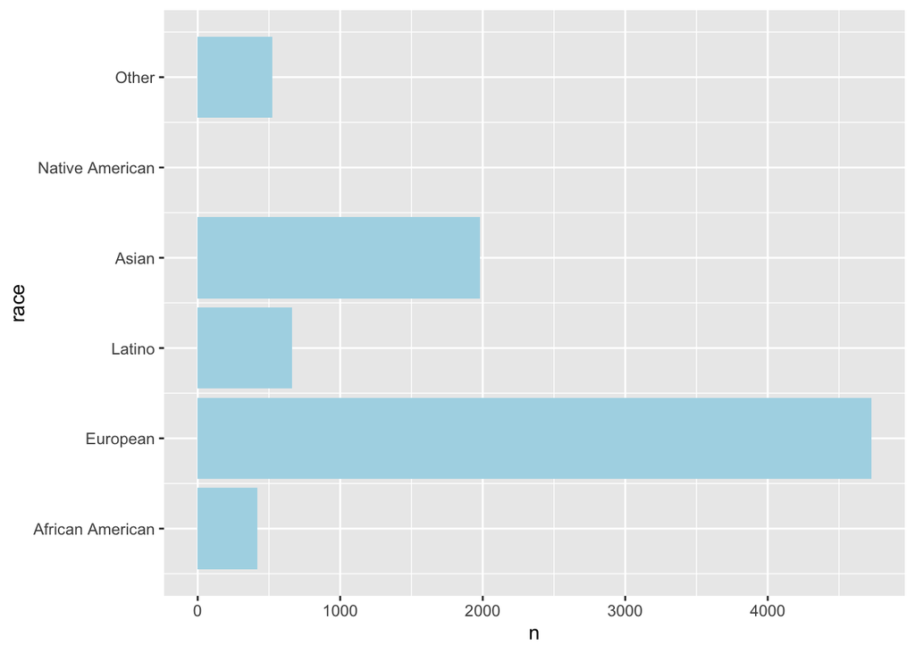

```r
#Visualize the whole population
sd_race %>%
  group_by(race) %>%
  summarise(n=n(), groups = 'drop') %>%
  ggplot(aes(x = race, y = n)) +
  geom_histogram(stat = 'identity', fill = 'lightblue') +
  scale_x_continuous(breaks = seq(1, 6), labels = race_des) +
  coord_flip()
```

The plot above shows one interesting point that there are no native Americans participate in the speed dating activity.

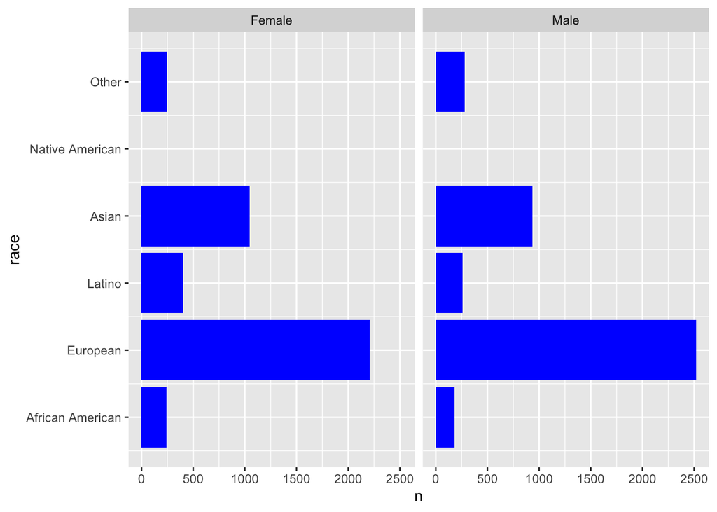

```r
#Visualize distribution of 'race' based on gender
sd_race %>%
  group_by(gender, race) %>%
  summarise(n=n(), groups = 'drop') %>%
  ggplot(aes(x = race, y = n)) +
  geom_histogram(stat = 'identity', fill = 'blue') +
  scale_x_continuous(breaks = seq(1, 6), labels = race_des) +
  coord_flip() +
  facet_grid(~gender)
```

Based on plots above, we can see that the distribution of race is roughly similar for both males and females.

### Q2: What is the distribution of the goal for speed dating?

```r
# Check if there are 'NAs' in the 'goal' column
sum(is.na(speed_dating$goal == 'NA'))
```

```
## [1] 79
```

It shows that there are 79 NAs in the goal column, and we might delete them for visualizing the distribution of ‘goal’.

```r
# Further data-cleaning (delete rows containing 'NA' in the 'goal' column)
sd_goal <- speed_dating[!is.na(speed_dating$goal),]
```

```r
#Prepare descriptions for numerical value of goals
#(Seemed like a fun night out=1
# To meet new people=2
# To get a date=3
# Looking for a serious relationship=4
# To say I did it=5
# Other=6)

goal_des <- c('Seemed like a fun night out', 'To meet new people', 'To get a date', 'Looking for a serious relationship', 'To say I did it', 'Other')
```

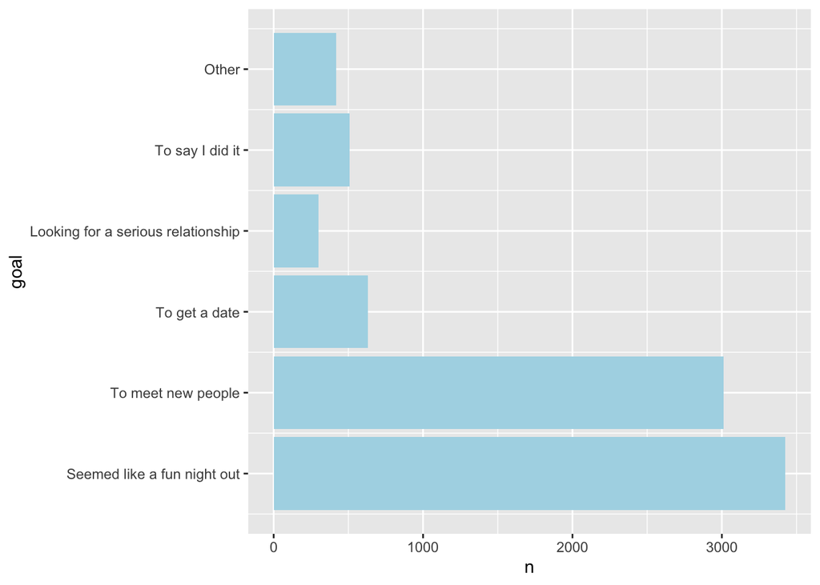

```r
#Visualize the whole population
sd_goal %>%
  group_by(goal) %>%
  summarise(n=n(), groups = 'drop') %>%
  ggplot(aes(x = goal, y = n)) +
  geom_histogram(stat = 'identity', fill = 'lightblue') +
  scale_x_continuous(breaks = seq(1, 6), labels = goal_des) +
  coord_flip()
```

The plot above shows that most people choose speed dating for ‘a fun night out’.

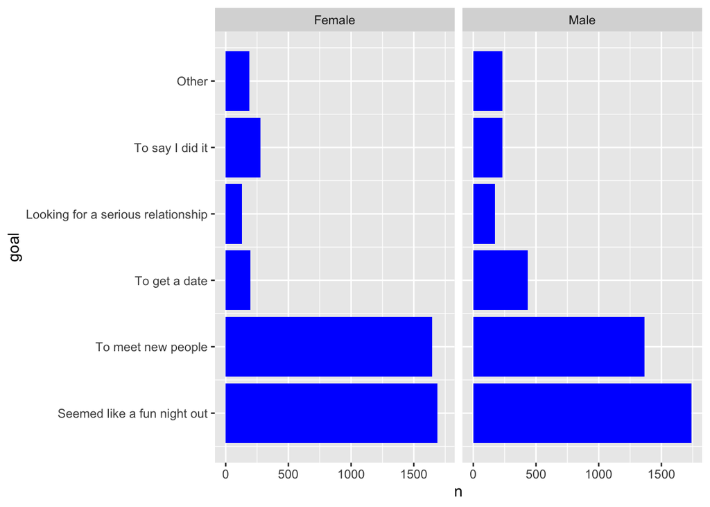

```r
#Visualize distribution of 'goal' based on gender
sd_goal %>%
  group_by(gender, goal) %>%
  summarise(n=n(), groups = 'drop') %>%
  ggplot(aes(x = goal, y = n)) +
  geom_histogram(stat = 'identity', fill = 'blue') +
  scale_x_continuous(breaks = seq(1, 6), labels = goal_des) +
  coord_flip() +
  facet_grid(~gender)
```

From the plots above, we can see that both genders choose speed dating for ‘a fun night out’. Another thing worth noting is that for female, the goals of ‘meeting new people’ and ‘fun night out’ have similar number of people.

# Orator: Xiaowen Xie and Kunxuan He

### Q1: What is the age distribution for speed dating people? How’s the age distributed in gender?

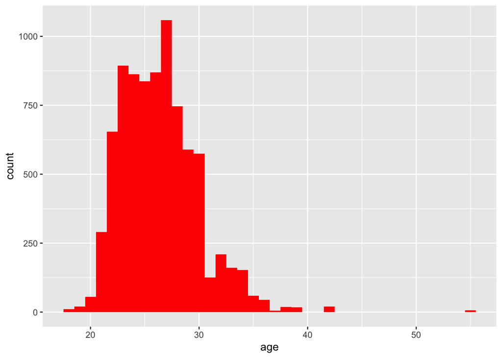

```r
#Histogram
speed_dating %>%
  ggplot(aes(age)) +
  geom_histogram(fill = 'red', binwidth = 1)
```

```r
#NUmber of people in different age groups
speed_dating %>%
  group_by(age) %>%
  count(age) %>%
  arrange(desc(n))
```

```
## # A tibble: 25 × 2
## # Groups:   age [25]
##      age     n
##    <int> <int>
##  1    27  1059
##  2    23   894
##  3    26   869
##  4    24   863
##  5    25   837
##  6    28   746
##  7    22   655
##  8    29   589
##  9    30   574
## 10    21   291
## # … with 15 more rows
```

We conclude that people at age 27 contribute significant number of speed-datings.

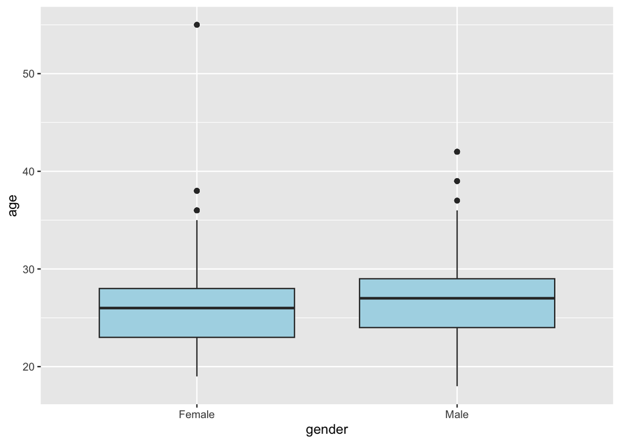

```r
speed_dating %>%
  ggplot(aes(x=gender, y=age)) +
  geom_boxplot(fill = 'lightblue')
```

### Q2: How is the distribution of successful & unsuccessful match among different age groups?

```r
# Check if there are 'NAs' in the 'match' column
sum(is.na(speed_dating$match == 'NA'))
```

```
## [1] 0
```

It shows that there are 0 NA in the ‘match’ column.

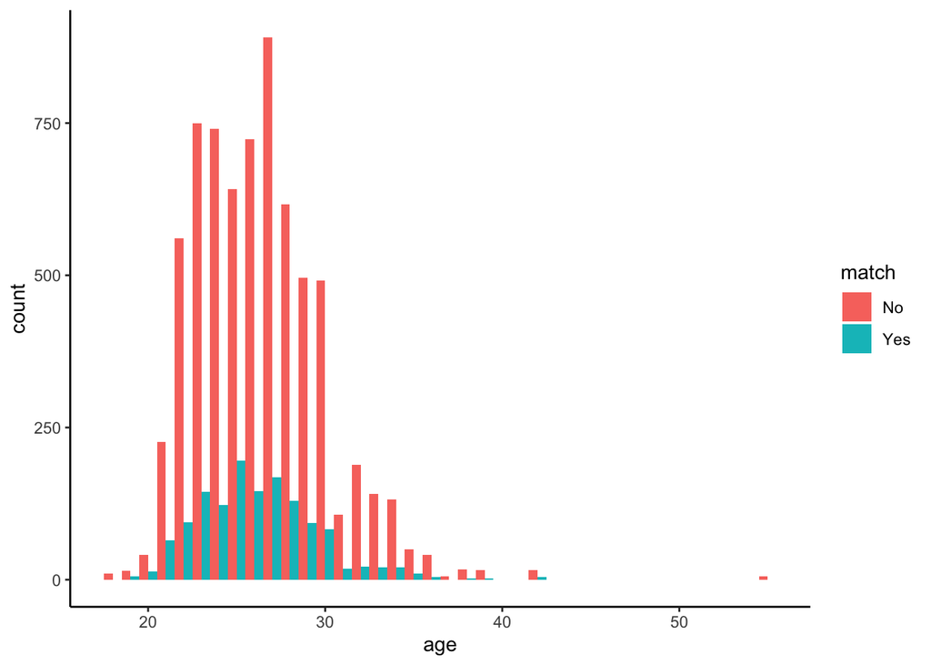

```r
#Visualize
speed_dating %>%
  ggplot(aes(x = age, fill = match)) +
  geom_histogram(position = position_dodge(), binwidth = 1) +
  theme_classic()
```

The plot above shows that the distribution of ‘match’ is roughly normally distributed among different age groups. The highest number of ‘match’ appears at age 25. On the other hand, the distribution of ‘non-match’ is right skewed. While most ‘non-match’ happen between age 20-30, some ‘non-matches’ exist in the age group greater than 30. We can also see that the number of unsuccessful matches is more than the number of successful matches among all age groups.

# Deliverer: Yunbing Bai

### Q1: Which study field has the most interest in speed dating? Which study field has the least interest in speed dating? How’s it distributed in different gender group?

```r
# Check if there are NAs in the column of field_code
sum(is.na(speed_dating$match == 'NA'))
```

```
## [1] 0
```

```r
#Prepare descriptions for numerical value of field_code
#(1= Law
#2= Math
#3= Social Science, Psychologist
#4= Medical Science, Pharmaceuticals, and Bio Tech
#5= Engineering
#6= English/Creative Writing/ Journalism
#7= History/Religion/Philosophy
#8= Business/Econ/Finance
#9= Education, Academia
#10= Biological Sciences/Chemistry/Physics
#11= Social Work
#12= Undergrad/undecided
#13= Political Science/International Affairs
#14= Film
#15= Fine Arts/Arts Administration
#16= Languages
#17= Architecture
#18= Other
fd_des <- c('Law', 'Math', 'Social Science, Psychologist', 'Medical Science, Pharmaceuticals, and Bio Tech', 'Engineering', 'English/Creative Writing/ Journalism', 'History/Religion/Philosophy', 'Business/Econ/Finance', 'Education, Academia', 'Biological Sciences/Chemistry/Physics', 'Social Work', 'Undergrad/undecided', 'Political Science/International Affairs', 'Film', 'Fine Arts/Arts Administration', 'Languages', 'Architecture', 'Other')
```

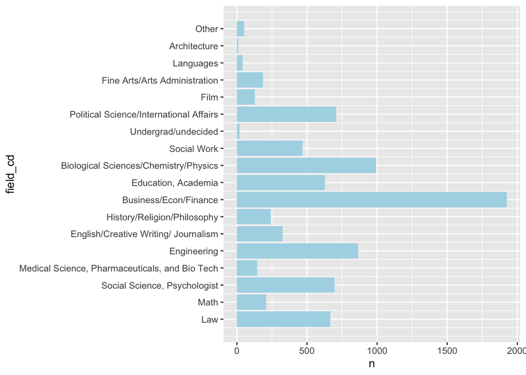

```r
#Visualize the whole population
speed_dating %>%
  group_by(field_cd) %>%
  summarise(n=n(), groups = 'drop') %>%
  ggplot(aes(x = field_cd, y = n)) +
  geom_histogram(stat = 'identity', fill = 'lightblue') +
  scale_x_continuous(breaks = seq(1, 18), labels = fd_des) +
  coord_flip()
```

From the plot above, we can see that most people who are interested in speed-dating mostly major in Business/Economics/Finance.

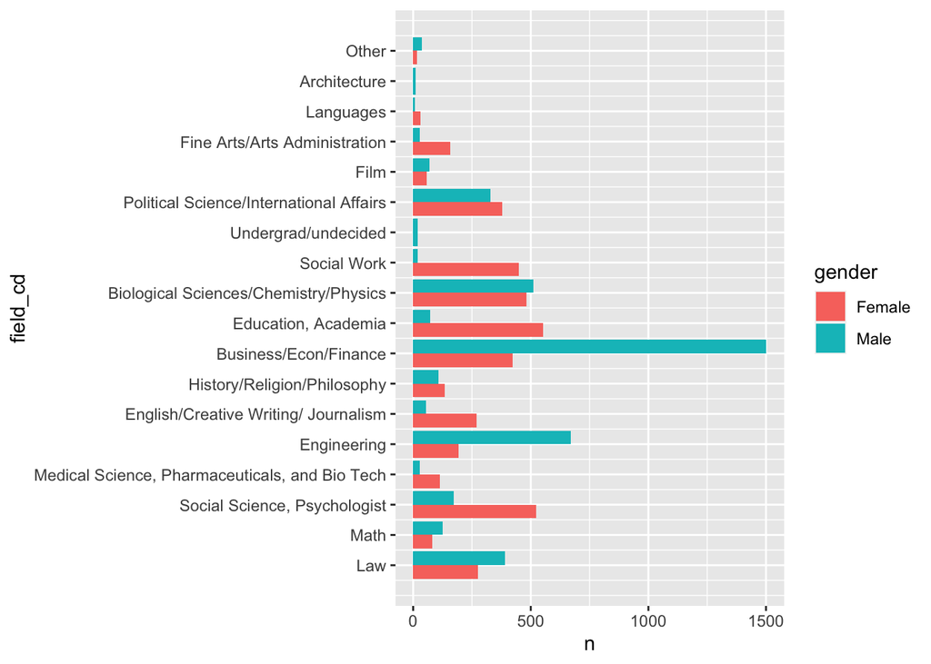

```r
#Visualize the distribution in diffeerent gender group
speed_dating %>%
  group_by(field_cd, gender) %>%
  summarise(n=n(), groups = 'drop') %>%
  ggplot(aes(x = field_cd, y = n, fill = gender)) +
  geom_histogram(stat = 'identity', position = 'dodge') +
  scale_x_continuous(breaks = seq(1, 18), labels = fd_des) +
  coord_flip()
```

From the plot above, we can see that most males who are interested in speed-dating mostly major in Business/Economics/Finance. Females majoring in Education, Academia are mostly interested in speed-dating.

### Q2: Which parameters have the most significant influence on the match result?

```r
#pick all data from surveys before the end of event (sign up sheet and scorecard)
sgf = subset(df,select = c(match,gender,int_corr,samerace,age_o,pf_o_att,pf_o_sin,pf_o_int,
                           pf_o_fun,pf_o_amb,pf_o_sha,dec_o,attr_o,sinc_o,intel_o,fun_o,
                           amb_o,shar_o,like_o,prob_o,met_o,age,imprace,imprelig,goal,date,go_out,
                           sports,tvsports,exercise,dining, museums,    art,    hiking, gaming, clubbing,
                           reading, tv, theater,    movies, concerts,   music,  shopping,   yoga,   exphappy,   expnum,
                           attr1_1, sinc1_1,    intel1_1,   fun1_1, amb1_1, shar1_1,    attr2_1,    sinc2_1,    intel2_1,
                           fun2_1,  amb2_1, shar2_1,    attr3_1,    sinc3_1,    fun3_1, intel3_1,   amb3_1, dec,
                           attr,    sinc,   intel,  fun,    amb,    shar,   like,   prob,   met))
#build correlation table and get correlation of "match"
cormat = round(cor(na.omit(sgf)),2)
sort(cormat[,1],decreasing = TRUE)
```

```
##    match    dec_o      dec   like_o     like   shar_o     shar   attr_o
##     1.00     0.57     0.57     0.35     0.35     0.33     0.33     0.31
##   prob_o     attr     prob    fun_o      fun   expnum  intel_o   fun3_1
##     0.31     0.31     0.31     0.29     0.29     0.18     0.16     0.16
##    intel   sinc_o    amb_o clubbing  attr3_1     sinc      amb concerts
##     0.16     0.15     0.15     0.15     0.15     0.15     0.15     0.13
##    music     yoga pf_o_fun   fun1_1 exphappy   amb3_1      art intel3_1
##     0.12     0.11     0.10     0.10     0.09     0.07     0.06     0.06
## samerace   movies int_corr   dining intel2_1  museums shopping pf_o_sha
##     0.05     0.05     0.04     0.04     0.03     0.02     0.02     0.01
##   sports  shar1_1  shar2_1   gender   hiking  reading  attr2_1  sinc2_1
##     0.01     0.01     0.01     0.00     0.00     0.00     0.00     0.00
## pf_o_att pf_o_amb   gaming  attr1_1   amb1_1   fun2_1 pf_o_sin pf_o_int
##    -0.02    -0.02    -0.02    -0.02    -0.02    -0.02    -0.03    -0.03
## exercise  theater  sinc1_1 intel1_1   amb2_1  sinc3_1       tv tvsports
##    -0.03    -0.03    -0.03    -0.03    -0.03    -0.03    -0.04    -0.05
##     goal    age_o      age     date    met_o imprelig   go_out      met
##    -0.07    -0.09    -0.09    -0.13    -0.15    -0.15    -0.15    -0.15
##  imprace
##    -0.18
```

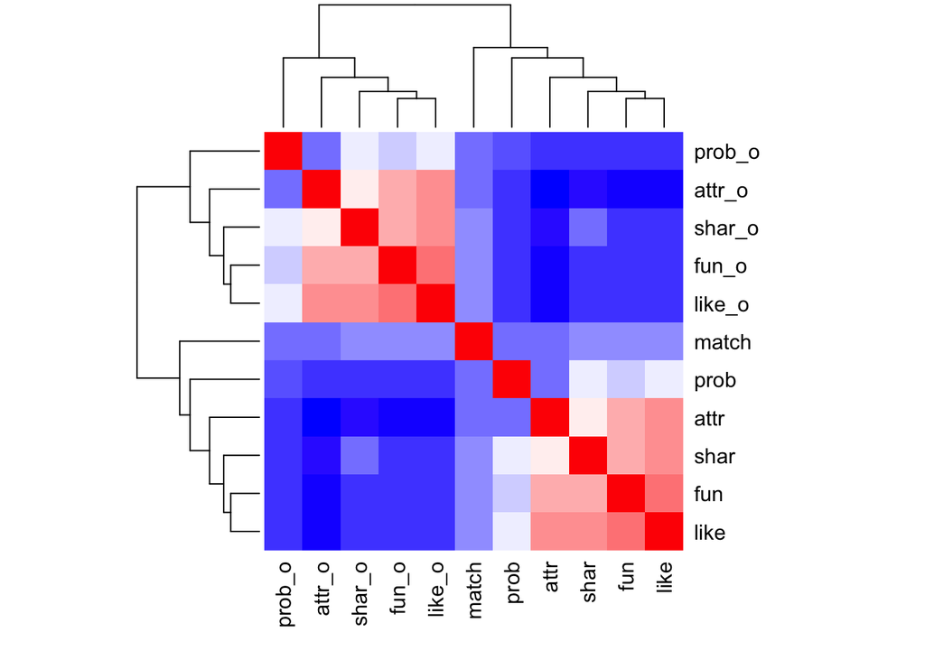

```r
#select high corr feature
my_data = subset(df,select=c(match,like_o,like,shar_o,shar,attr_o,prob_o,attr,prob,fun_o,fun))
#build heatmap of correlation table for high corr features
corr = cor(na.omit(my_data))
col = colorRampPalette(c("blue", "white", "red"))(20)
heatmap(x = corr, col = col,symm=TRUE)
```

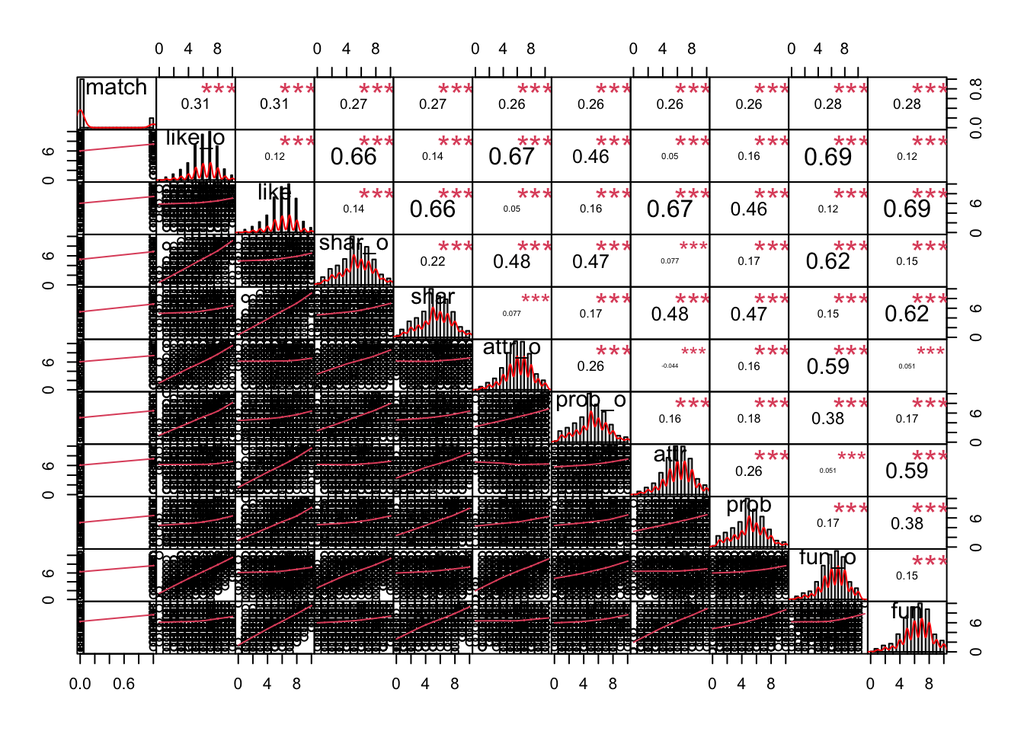

```r
#get more detailed information of correlation table
chart.Correlation(my_data, histogram=TRUE, pch=19)
```

```r
# based on the heatmap, we can see individually all of features do not have high correlation with match. Following features have relatively high correlation with match:
#like: over all score of how much this member like the partner.(rate by member)
#like_o: over all score of how much the partner like this member (rate by partner)
#shar: over all score of this member shared same hobbies with the partner.(rate by member)
#shar_o: over all score of the partner shared same hobbies with this member.(rate by partner)
#attr_o: rating by partner for member, based on all 6 attributes (attractive,sincere,intelligent,fun,ambitious,shared interests).
#attr:rating by member for partner, based on all 6 attributes (attractive,sincere,intelligent,fun,ambitious,shared interests).
#fun, fun_o: how they rate each other based on fun
#prob,prob_o: how they rate each based on question: How probable do you think it is that this person will say 'yes' for you?
```

# Follow-up Questions

### New Questions Based Off Initial Investigation

- Q1: What attributes(Attractive, Sincere, Intelligent, Fun, Ambitious, Shared Interests/Hobbies) are relatively important in a potential date for men and women?
- Q2: Is there a significant relationship between people’s income and their primary goal in participating of a date?
- Q3: Is there a correlation between the fields of study with the chance to get a match partner in speed match making? If so, which field of study has the greatest advantage in mate selection?
- Q4: Which parameters play the most important roles when they decide to keep dating after the event?

### Investigation of Follow-up Questions

Our group decided to investigate Q3 and Q4 in further detail.

# For Question 3

```r
dataset = dataset %>% drop_na(match,gender,field)
dataset_field_match = subset(dataset, match=="1")
match_count_field = data.frame(tabyl(dataset, match, field))
head(match_count_field)
```

[output not shown]

[output cut: 173 more lines]

[output not shown]

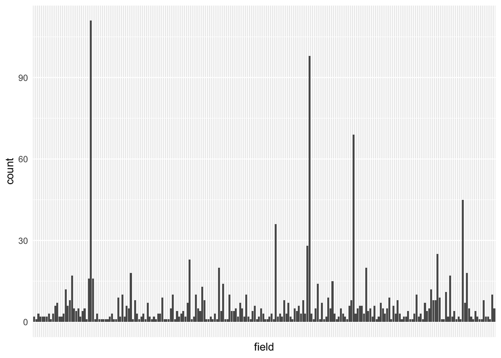

```r
ggplot(data.frame(dataset_field_match), aes(x=field)) +
  geom_bar()+theme(
      axis.text.x = element_blank(),
      axis.ticks = element_blank())
```

```r
match_count_field = data.frame(t(match_count_field[2,-1]))
```

From the plot, we can see that people who work in roughly five kind of field are likely get a match.

```r
sort(match_count_field$X2, decreasing = TRUE)[1:5]
```

```
## [1] 111  98  69  45  36
```

```r
rbind(subset(match_count_field,match_count_field==111),subset(match_count_field,match_count_field==98),subset(match_count_field,match_count_field==69),subset(match_count_field,match_count_field==45),subset(match_count_field,match_count_field==36))
```

```
##                        X2
## Business              111
## Law                    98
## MBA                    69
## Social.Work            45
## International.Affairs  36
```

Hence, we can see that people who work in Business, Law, MBA, Social.Work, and International.Affairs are likely get a match.

# For Question 4

```r
#pick all data from survey 3-4 weeks after the end of event (follow up 2)
sgf2 = subset(df,select = c(numdat_3,   num_in_3,   attr1_3,    sinc1_3,    intel1_3,   fun1_3, amb1_3, shar1_3,    attr7_3,    sinc7_3,
                           intel7_3,    fun7_3, amb7_3, shar7_3,    attr4_3,    sinc4_3,    intel4_3,   fun4_3, amb4_3,
                           shar4_3, attr2_3,    sinc2_3,    intel2_3,   fun2_3, amb2_3, shar2_3,    attr3_3,
                           sinc3_3, intel3_3,   fun3_3, amb3_3, attr5_3,    sinc5_3,    intel5_3,   fun5_3, amb5_3))
#calculate number of dates for each member, stored in num_date
sgf2$num_date = sgf2$numdat_3+sgf2$num_in_3

#sgf2 = subset(sgf2,select = -c(numdat_3,   num_in_3))%>%
  #dplyr::filter(!is.na(num_date))

#build correlation table and get correlation of "num_date"
cormat2 = round(cor(na.omit(sgf2)),2)
sort(cormat2[,length(cormat2[,1])],decreasing = TRUE)
```

```
## num_date numdat_3 num_in_3   amb2_3 intel4_3  attr3_3   fun4_3  shar4_3
##     1.00     0.89     0.68     0.42     0.37     0.36     0.24     0.23
##  shar2_3  shar7_3  sinc4_3 intel2_3 intel3_3   amb3_3  attr5_3   fun5_3
##     0.22     0.21     0.19     0.19     0.19     0.17     0.17     0.16
##   fun7_3   fun3_3   fun2_3  sinc7_3  sinc2_3   fun1_3  sinc3_3  sinc5_3
##     0.14     0.14     0.08     0.07     0.05     0.03     0.03     0.03
##  attr1_3 intel1_3 intel5_3   amb4_3   amb5_3  sinc1_3  attr7_3 intel7_3
##     0.00     0.00    -0.02    -0.05    -0.05    -0.06    -0.06    -0.08
##   amb1_3  shar1_3  attr4_3   amb7_3  attr2_3
##    -0.09    -0.13    -0.33    -0.37    -0.38
```

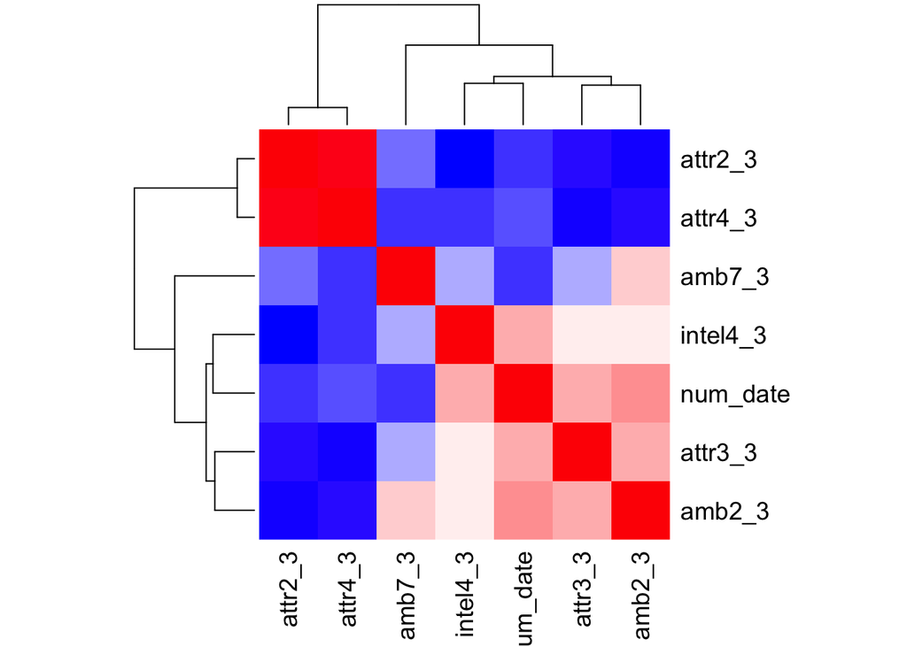

```r
#select high corr feature
my_data2 = subset(sgf2,select=c(num_date,amb2_3,intel4_3,attr3_3,attr4_3, amb7_3,attr2_3))
#build heatmap of correlation table for high corr features
corr2 = cor(na.omit(my_data2))
col = colorRampPalette(c("blue", "white", "red"))(20)
heatmap(x = corr2, col = col,symm=TRUE)
```

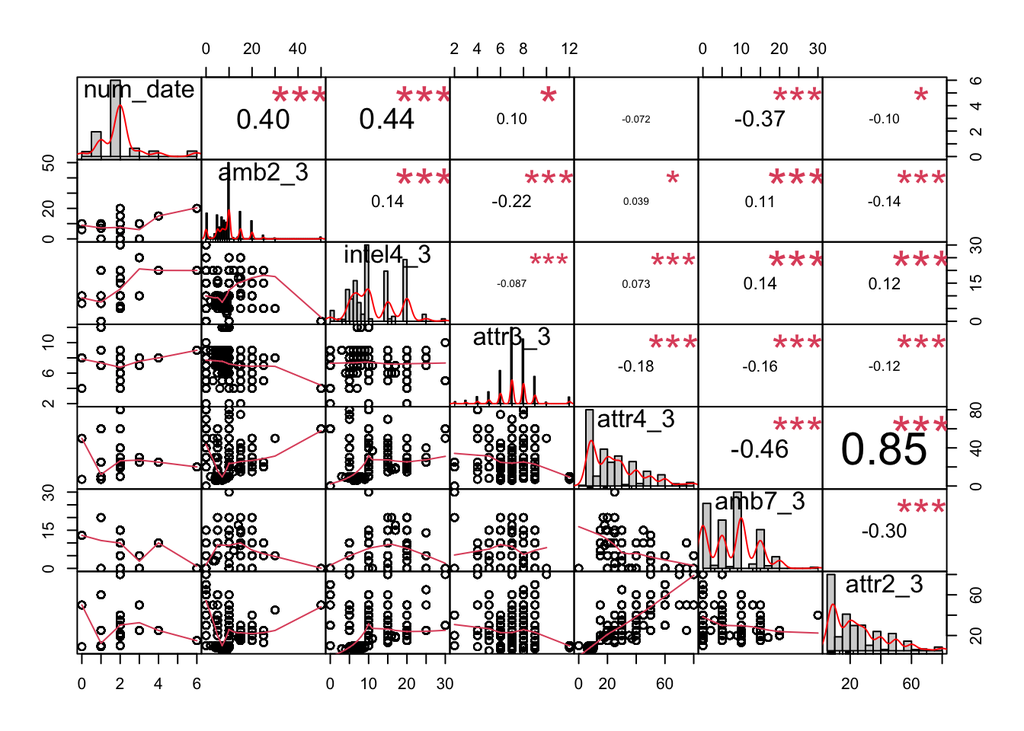

```r
#get more detailed information of correlation table
chart.Correlation(my_data2, histogram=TRUE, pch=19)
```

```r
# based on the heatmap, we can see individually all of features do not have high correlation with number of dates. Following features have relatively high correlation with number of future dates for each member:
#amb2_3:What do you think the opposite sex looks for a person who is ambitious in a date?
#attr2_3: What do you think the opposite sex looks for a person who is attractive in a date?
#attr3_3: rate your opinion of your own attractive
#attr4_3: rate the importance of attractive
#intel4_3: rate the importance of inteligent
#amb7_3: best reflects the actual importance of ambitious in your decisions.
```

# Summary

[output not shown]